# Exploratory Analysis

Steven Luong, Bridget Haney, Emma Dickenson, Jennifer Li

## Distribution of Variables

### Obesity and Poverty Rates

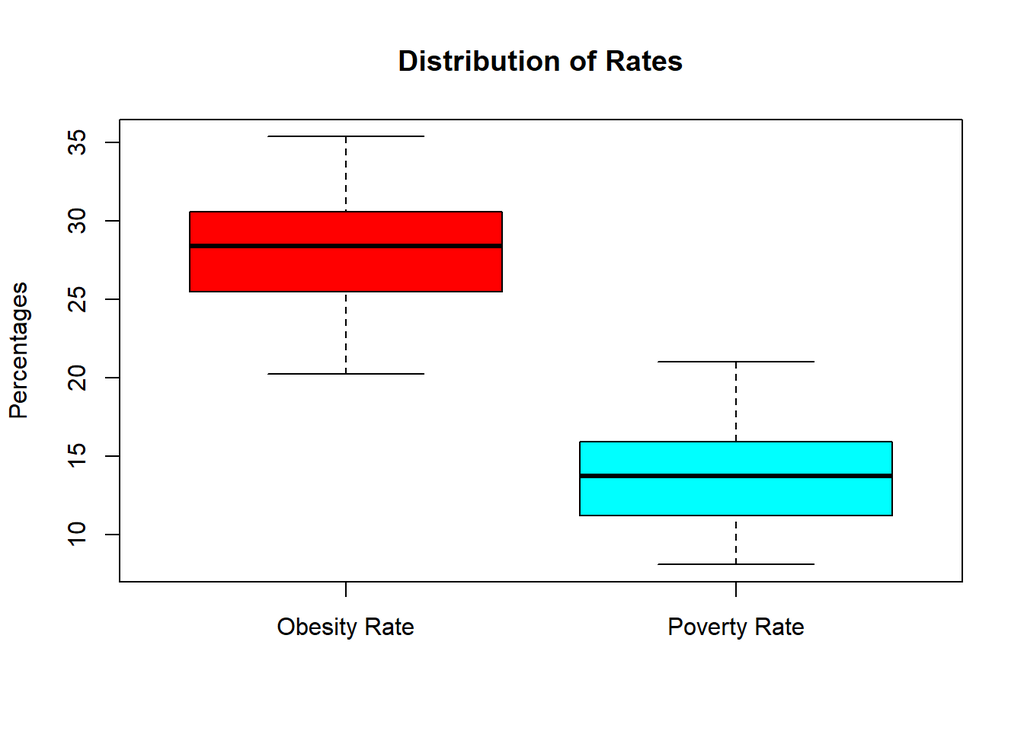

### Average Income Distribution Across Four Years

**Average Income Summary**

To further define the causes of obesity within the United States, a prevalent starting point is average income. The selected dataset provides average income for all fifty states across four years: 2014, 2015, 2016, and 2017. Here is a table of summary statistics:

| Year | Mean Income | Minimum Income | Median Income | Maximum Income |
| --- | --- | --- | --- | --- |
| 2014 | 28492.70 | 20921.02 | 27577.36 | 39482.45 |
| 2015 | 29561.64 | 21243.15 | 28716.05 | 39629.65 |
| 2016 | 30486.15 | 23041.79 | 29141.26 | 41122.31 |
| 2017 | 31619.60 | 23124.98 | 30476.82 | 41961.14 |

In visually represent the distribution of average income across four years, the box plots below demonstrate relevant metrics such as means, medians, minimums, maximums, interquartile range data, and any outliers.

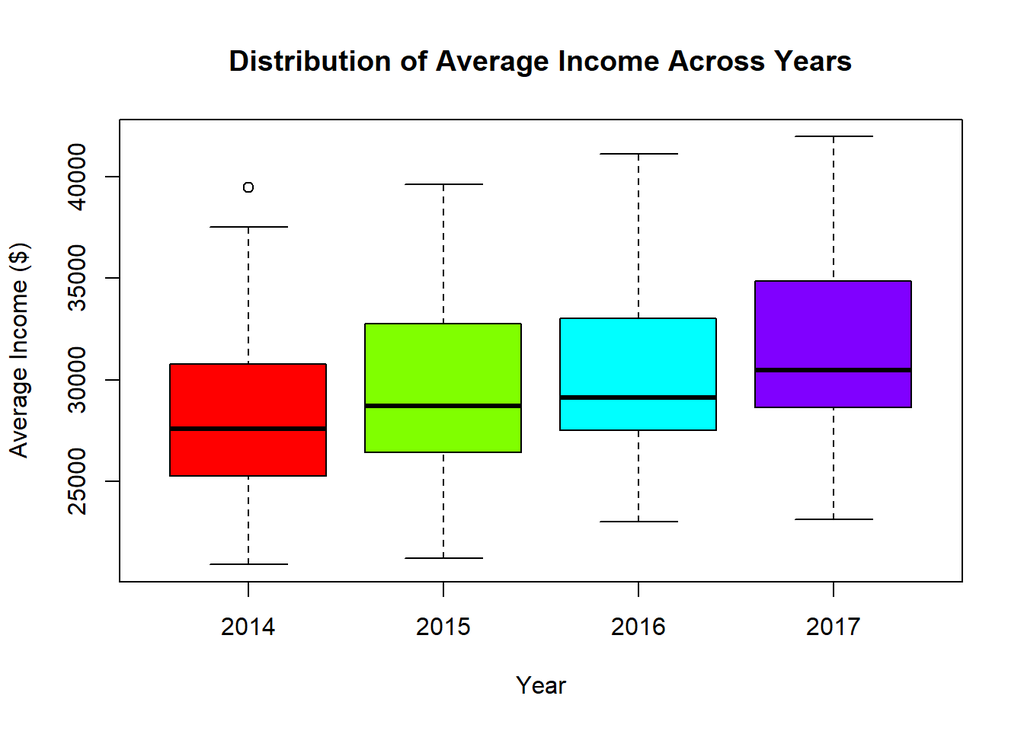

## Relationships Between Variables

### Effects Of Wealth and Obesity

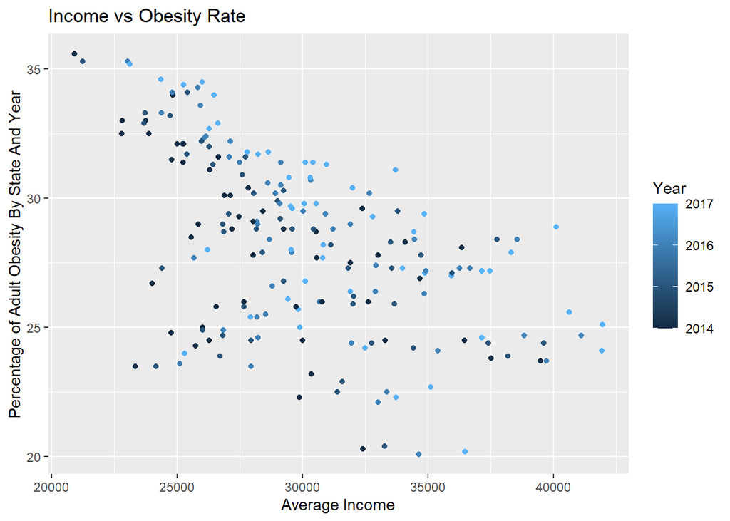

Unsuprisingly, we see a correlation between income and obesity. In general as the average income increases, we see the obesity rate decreases as well. This isn’t a surprise due to the issue that less wealthy people are more likely to live in food deserts and have less access to purchasing healthier foods. Another issue that can influence this correlation is that junk food are typically cheaper than healthier foods. We see this with fast food restaurants and how they are able to offer very cheap meals as compared to a standard restaurant.

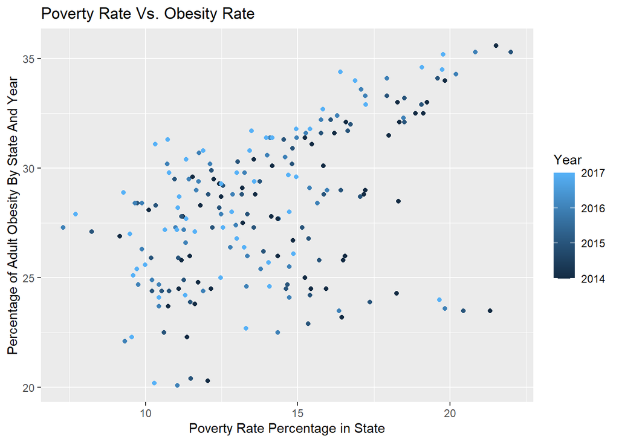

We continue to see the trend with wealth and obesity rates as well when we compare poverty rates and obestiy rates. In this graph, we see that as poverty rates rises, so does the obesity rate. This falls in line with our conclusions with average income because income is the determining factor if someone lives in poverty or not.

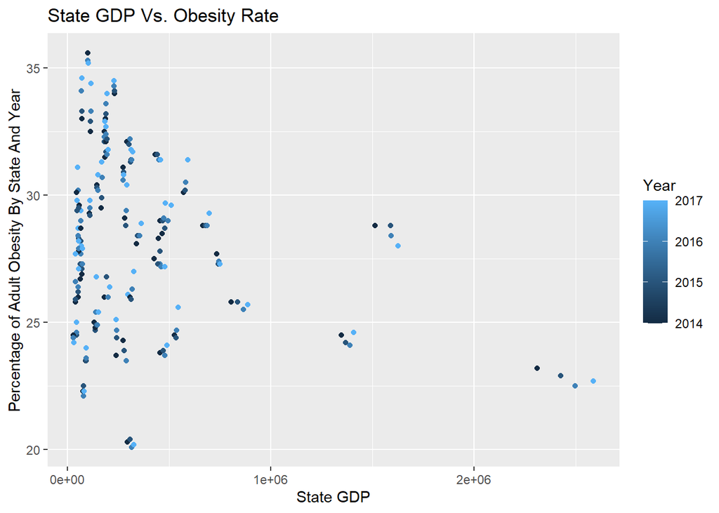

Finally, comparing a state’s GDP to its obesity rate, we see that there isn’t a strong correlation between the two. This is highly surprising because the previous two charts display a fairly strong correlation between wealth and obesity while as we see in this chart, a state’s GDP typically doesn’t affect the obesity rates of its state. Although, we can see that the wealthier states have a relatively low obesity rate, the poorer states have a large variation of obesity rates. This draws into question if there are other factors, such as region, that can cause such a large disparity among the poor states.

Another interesting trend we see in all three charts is that the years, which are color coded on the graphs are distrubuted quite evenly. We do not see clusters of obesity and income rates for certain years which suggests that there is not a signicant change in income or obesity levels as time goes on. However, our data is limited from 2014-2017 so further research will be needed to better determine how obesity levels change with time.

### Obesity Rates Across Regions

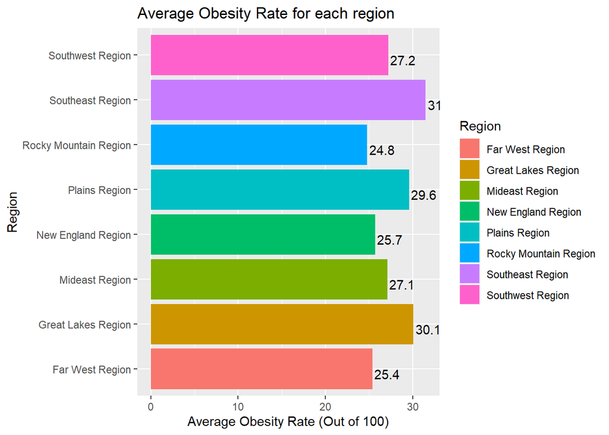

Since the higher obesity rate regions and the lower obesity rate regions are scattered, we can conclude that there is no strong correlation between region and obesity rates. One possible explaination for why southeast region has the highest obesity rate could be because that there is more urban area in the southeast region.